# Red Wine Exploration

Olivia Jonah

March 9, 2017

### Introduction

This study is going to analyze wine data created by Paulo Cortez (Univ. Minho), Antonio Cerdeira, Fernando Almeida, Telmo Matos and Jose Reis (CVRVV) @ 2009. it shows how certain varibles can affect the quality of wine.

# Univariate Plots Section

## Database Structure

[1] “Dataset variables”

- X
- fixed.acidity
- volatile.acidity
- citric.acid
- residual.sugar
- chlorides
- free.sulfur.dioxide
- total.sulfur.dioxide
- density
- pH
- sulphates
- alcohol
- quality
- rating

```
## 'data.frame':    1599 obs. of  14 variables:
##  $ X                   : int  1 2 3 4 5 6 7 8 9 10 ...
##  $ fixed.acidity       : num  7.4 7.8 7.8 11.2 7.4 7.4 7.9 7.3 7.8 7.5 ...
##  $ volatile.acidity    : num  0.7 0.88 0.76 0.28 0.7 0.66 0.6 0.65 0.58 0.5 ...
##  $ citric.acid         : num  0 0 0.04 0.56 0 0 0.06 0 0.02 0.36 ...
##  $ residual.sugar      : num  1.9 2.6 2.3 1.9 1.9 1.8 1.6 1.2 2 6.1 ...
##  $ chlorides           : num  0.076 0.098 0.092 0.075 0.076 0.075 0.069 0.065 0.073 0.071 ...
##  $ free.sulfur.dioxide : num  11 25 15 17 11 13 15 15 9 17 ...
##  $ total.sulfur.dioxide: num  34 67 54 60 34 40 59 21 18 102 ...
##  $ density             : num  0.998 0.997 0.997 0.998 0.998 ...
##  $ pH                  : num  3.51 3.2 3.26 3.16 3.51 3.51 3.3 3.39 3.36 3.35 ...
##  $ sulphates           : num  0.56 0.68 0.65 0.58 0.56 0.56 0.46 0.47 0.57 0.8 ...
##  $ alcohol             : num  9.4 9.8 9.8 9.8 9.4 9.4 9.4 10 9.5 10.5 ...
##  $ quality             : Ord.factor w/ 6 levels "3"<"4"<"5"<"6"<..: 3 3 3 4 3 3 3 5 5 3 ...
##  $ rating              : Ord.factor w/ 3 levels "bad"<"average"<..: 2 2 2 2 2 2 2 3 3 2 ...
```

[output not shown]

Dataset summary (continued below)

| X | fixed.acidity | volatile.acidity | citric.acid | residual.sugar |
| --- | --- | --- | --- | --- |
| Min. : 1.0 | Min. : 4.60 | Min. :0.1200 | Min. :0.000 | Min. : 0.900 |
| 1st Qu.: 400.5 | 1st Qu.: 7.10 | 1st Qu.:0.3900 | 1st Qu.:0.090 | 1st Qu.: 1.900 |
| Median : 800.0 | Median : 7.90 | Median :0.5200 | Median :0.260 | Median : 2.200 |
| Mean : 800.0 | Mean : 8.32 | Mean :0.5278 | Mean :0.271 | Mean : 2.539 |
| 3rd Qu.:1199.5 | 3rd Qu.: 9.20 | 3rd Qu.:0.6400 | 3rd Qu.:0.420 | 3rd Qu.: 2.600 |
| Max. :1599.0 | Max. :15.90 | Max. :1.5800 | Max. :1.000 | Max. :15.500 |

Table continues below

| chlorides | free.sulfur.dioxide | total.sulfur.dioxide | density |
| --- | --- | --- | --- |
| Min. :0.01200 | Min. : 1.00 | Min. : 6.00 | Min. :0.9901 |
| 1st Qu.:0.07000 | 1st Qu.: 7.00 | 1st Qu.: 22.00 | 1st Qu.:0.9956 |
| Median :0.07900 | Median :14.00 | Median : 38.00 | Median :0.9968 |
| Mean :0.08747 | Mean :15.87 | Mean : 46.47 | Mean :0.9967 |
| 3rd Qu.:0.09000 | 3rd Qu.:21.00 | 3rd Qu.: 62.00 | 3rd Qu.:0.9978 |
| Max. :0.61100 | Max. :72.00 | Max. :289.00 | Max. :1.0037 |

| pH | sulphates | alcohol | quality | rating |
| --- | --- | --- | --- | --- |
| Min. :2.740 | Min. :0.3300 | Min. : 8.40 | 3: 10 | bad : 63 |
| 1st Qu.:3.210 | 1st Qu.:0.5500 | 1st Qu.: 9.50 | 4: 53 | average:1319 |
| Median :3.310 | Median :0.6200 | Median :10.20 | 5:681 | good : 217 |
| Mean :3.311 | Mean :0.6581 | Mean :10.42 | 6:638 | NA |
| 3rd Qu.:3.400 | 3rd Qu.:0.7300 | 3rd Qu.:11.10 | 7:199 | NA |
| Max. :4.010 | Max. :2.0000 | Max. :14.90 | 8: 18 | NA |

To be able to choose what assumptions can be made when applying statistical tests, each individual distribution will be explored.

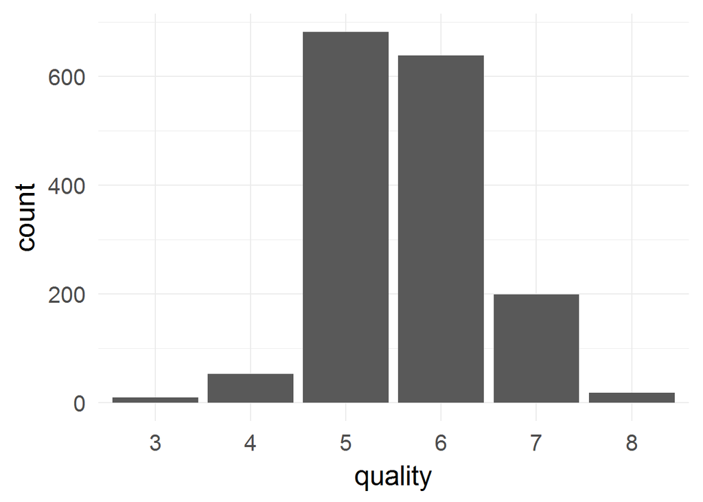

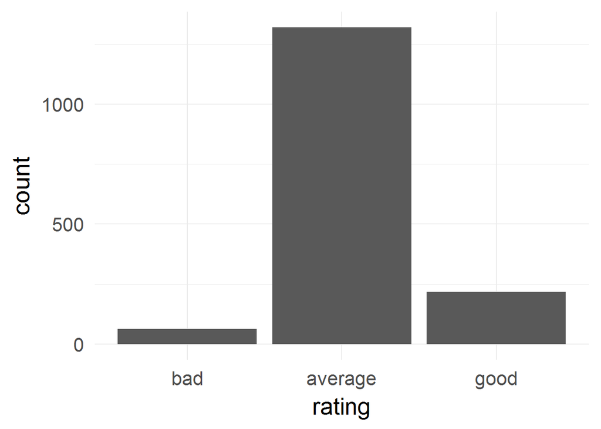

The plot above shows a high average ratings of wines (high concentration of wines in the center region) and there are noticabley no outliers, this might be a problem for generating a predicting model later on.

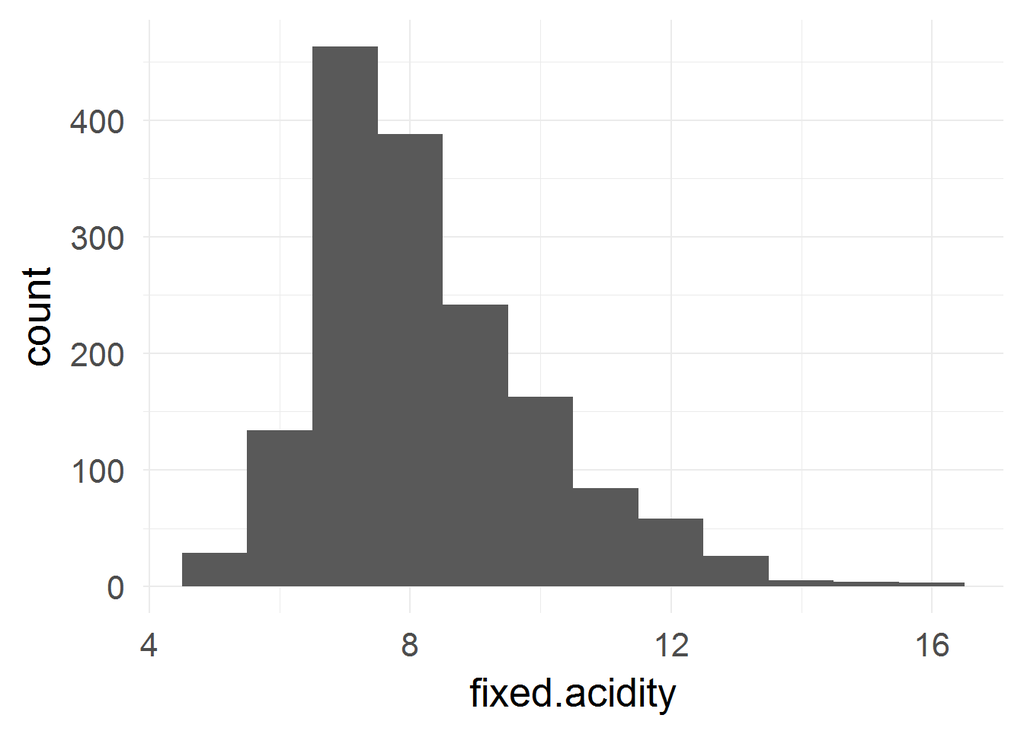

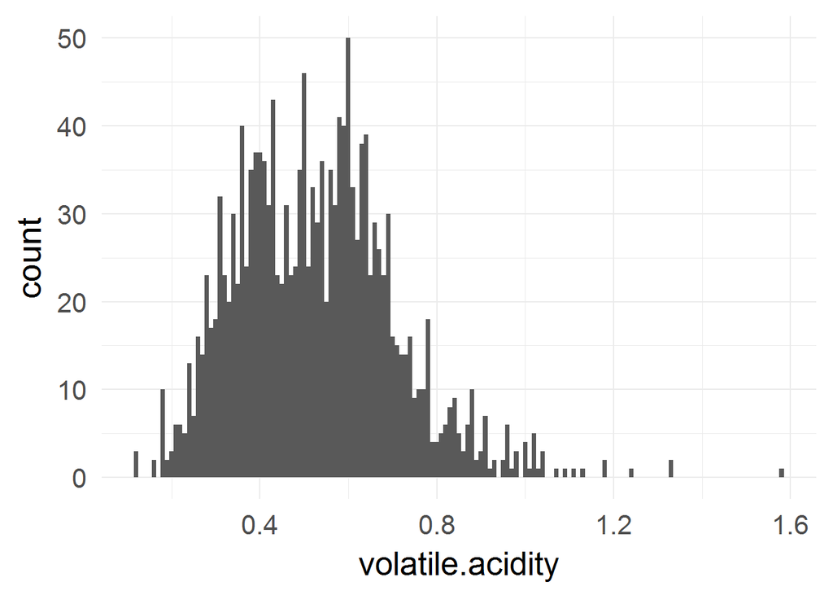

This shows a normal distribution

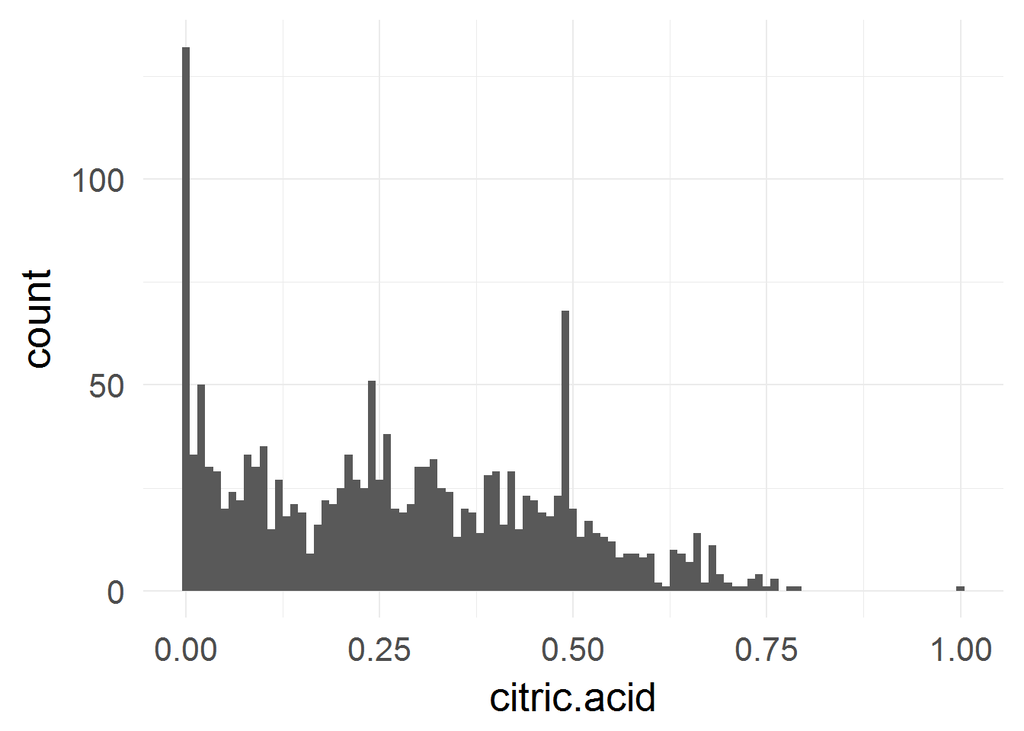

Now this is strange distribution. 8% of wines do not present critic acid at all. Maybe a problem in the data collection process?

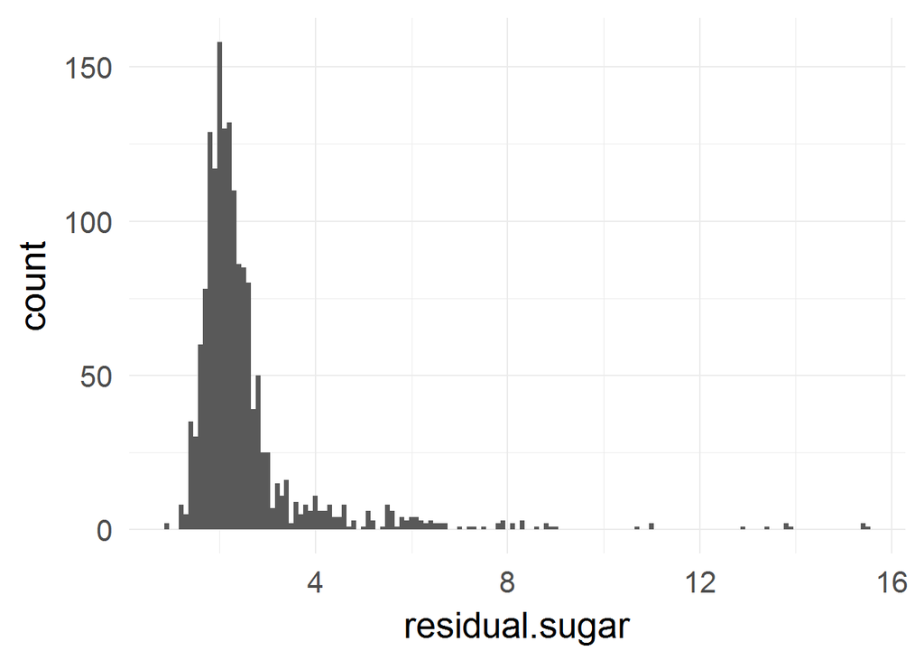

Median 2.2 ( high concentration) with some outliers along the higher ranges.

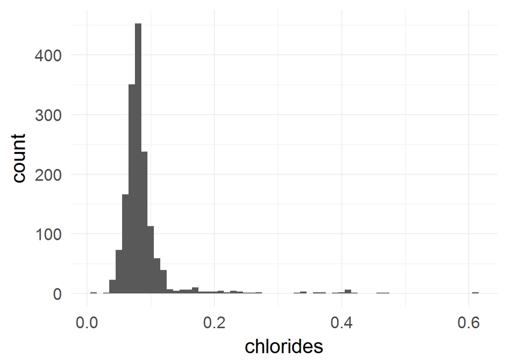

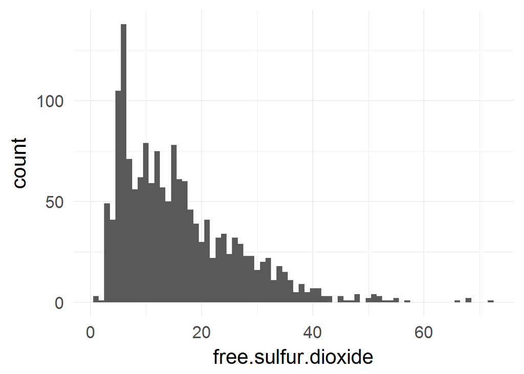

The distributions peaks at around aroun 7 and from then on resembles a long tailed distribution with very few wines over 60.

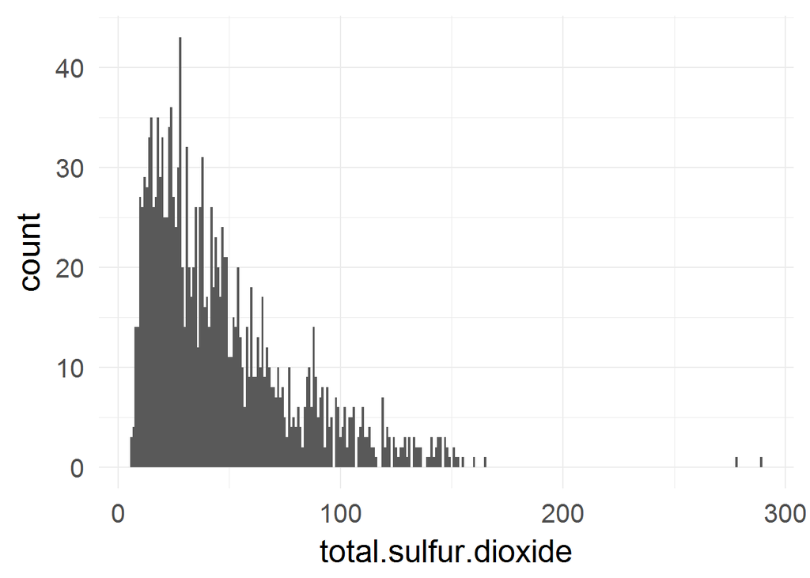

long tailed distribution

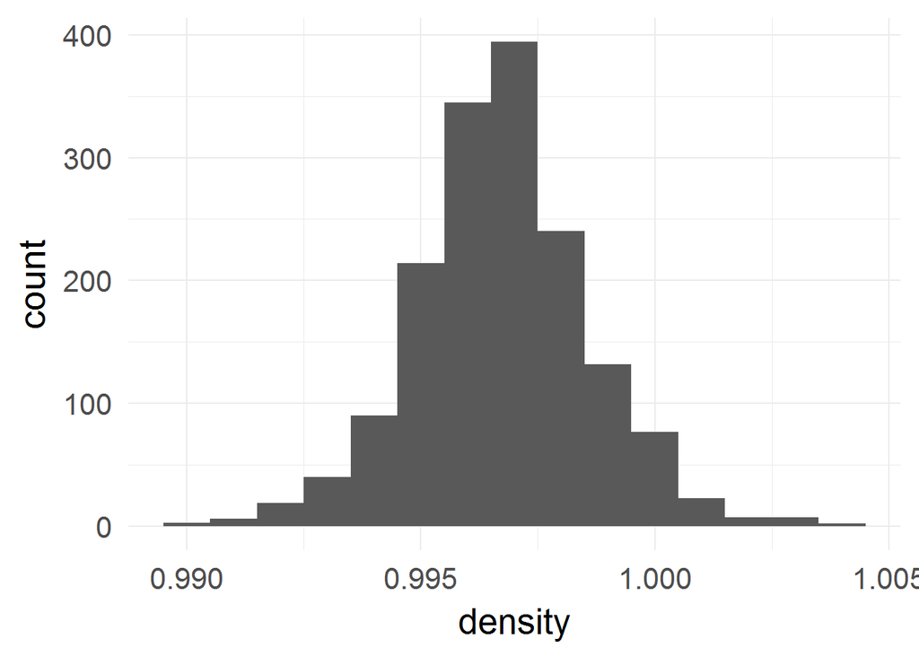

This is a normal distribution for density.

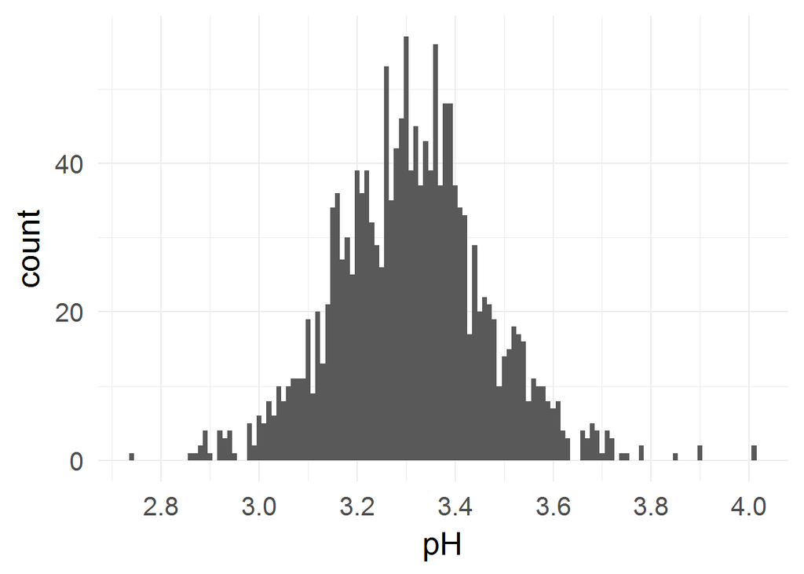

pH also looks normally distributed.

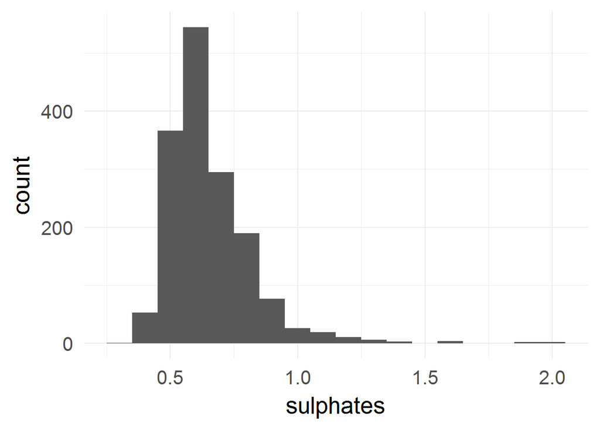

For sulphates we see a distribution similar to the ones of residual.sugar and chlorides.

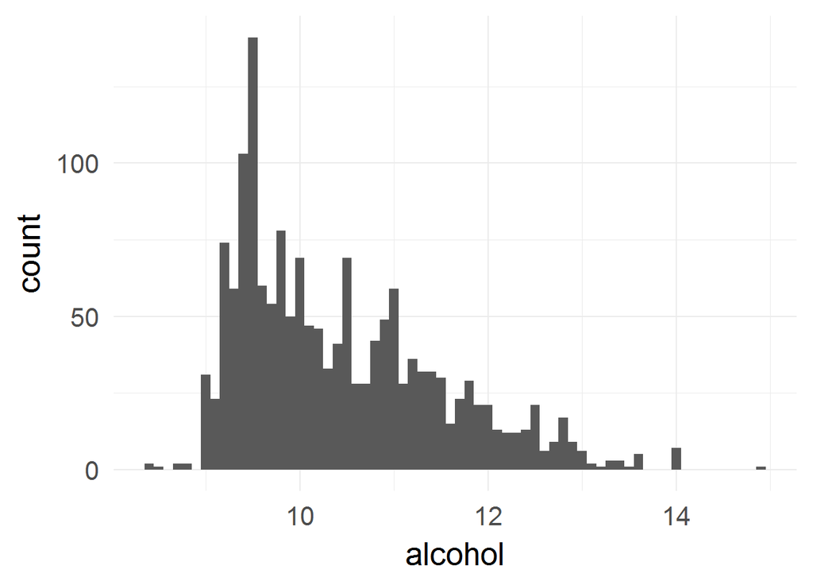

Rapid increase and then long tailed distribution as seen in sulfur.dioxide, maybe there is a correlation between the variables.

# Univariate Analysis

### What is the structure of your dataset?

There are 1599 observation of wines in the dataset with 14 features . There is one categorical variable (quality) and the others are numerical variables indicating physical and chemical properties of the wine.

Other observations: The median quality is 6, which in the given scale (1-10) is a mediocre wine. The better wine in the sample has a score of 8, and the worst has a score of 3. The dataset is not balanced, that is, there are a more average wines than poor or excelent ones and this might prove challenging when designing a predicting algorithm.

### What is/are the main feature(s) of interest in your dataset?

The main feature in the data is quality. I’d like to determine which features determine the quality of wines.

### What other features in the dataset do you think will help support your

investigation into your feature(s) of interest? The variables related to acidity (fixed, volatile, citric.acid and pH) might explain some of the variance. Maybe the different acid concentrations might alter the taste of the wine. Also, residual.sugar dictates how sweet a wine is and might also have an influence in taste.

### Did you create any new variables from existing variables in the dataset?

A rating variable was created to improve the later visualizations.

### Of the features you investigated, were there any unusual distributions? Did

you perform any operations on the data to tidy, adjust, or change the form of the data? If so, why did you do this?

Citric.acid stood out from the other distributions. It had (apart from some outliers) an retangularly looking distribution which given the wine quality distribution seems very unexpected.

# Bivariate Plots Section

A correlation table for all variables will help us understand the relationships between them.

Table continues below

|  | X | fixed.acidity | volatile.acidity |
| --- | --- | --- | --- |
| **X** | 1 | -0.2685 | -0.008815 |
| **fixed.acidity** | -0.2685 | 1 | -0.2561 |
| **volatile.acidity** | -0.008815 | -0.2561 | 1 |
| **citric.acid** | -0.1536 | **0.6717** | **-0.5525** |
| **residual.sugar** | -0.03126 | 0.1148 | 0.001918 |
| **chlorides** | -0.1199 | 0.09371 | 0.0613 |
| **free.sulfur.dioxide** | 0.09048 | -0.1538 | -0.0105 |
| **total.sulfur.dioxide** | -0.1178 | -0.1132 | 0.07647 |
| **density** | **-0.3684** | **0.668** | 0.02203 |
| **pH** | 0.136 | **-0.683** | 0.2349 |
| **sulphates** | -0.1253 | 0.183 | -0.261 |
| **alcohol** | 0.2451 | -0.06167 | -0.2023 |
| **quality** | 0.06645 | 0.1241 | **-0.3906** |

Table continues below

|  | citric.acid | residual.sugar | chlorides |
| --- | --- | --- | --- |
| **X** | -0.1536 | -0.03126 | -0.1199 |
| **fixed.acidity** | **0.6717** | 0.1148 | 0.09371 |
| **volatile.acidity** | **-0.5525** | 0.001918 | 0.0613 |
| **citric.acid** | 1 | 0.1436 | 0.2038 |
| **residual.sugar** | 0.1436 | 1 | 0.05561 |
| **chlorides** | 0.2038 | 0.05561 | 1 |
| **free.sulfur.dioxide** | -0.06098 | 0.187 | 0.005562 |
| **total.sulfur.dioxide** | 0.03553 | 0.203 | 0.0474 |
| **density** | **0.3649** | **0.3553** | 0.2006 |
| **pH** | **-0.5419** | -0.08565 | -0.265 |
| **sulphates** | **0.3128** | 0.005527 | **0.3713** |
| **alcohol** | 0.1099 | 0.04208 | -0.2211 |
| **quality** | 0.2264 | 0.01373 | -0.1289 |

Table continues below

|  | free.sulfur.dioxide | total.sulfur.dioxide |
| --- | --- | --- |
| **X** | 0.09048 | -0.1178 |
| **fixed.acidity** | -0.1538 | -0.1132 |
| **volatile.acidity** | -0.0105 | 0.07647 |
| **citric.acid** | -0.06098 | 0.03553 |
| **residual.sugar** | 0.187 | 0.203 |
| **chlorides** | 0.005562 | 0.0474 |
| **free.sulfur.dioxide** | 1 | **0.6677** |
| **total.sulfur.dioxide** | **0.6677** | 1 |
| **density** | -0.02195 | 0.07127 |
| **pH** | 0.07038 | -0.06649 |
| **sulphates** | 0.05166 | 0.04295 |
| **alcohol** | -0.06941 | -0.2057 |
| **quality** | -0.05066 | -0.1851 |

Table continues below

|  | density | pH | sulphates | alcohol |
| --- | --- | --- | --- | --- |
| **X** | **-0.3684** | 0.136 | -0.1253 | 0.2451 |
| **fixed.acidity** | **0.668** | **-0.683** | 0.183 | -0.06167 |
| **volatile.acidity** | 0.02203 | 0.2349 | -0.261 | -0.2023 |
| **citric.acid** | **0.3649** | **-0.5419** | **0.3128** | 0.1099 |
| **residual.sugar** | **0.3553** | -0.08565 | 0.005527 | 0.04208 |
| **chlorides** | 0.2006 | -0.265 | **0.3713** | -0.2211 |
| **free.sulfur.dioxide** | -0.02195 | 0.07038 | 0.05166 | -0.06941 |
| **total.sulfur.dioxide** | 0.07127 | -0.06649 | 0.04295 | -0.2057 |
| **density** | 1 | **-0.3417** | 0.1485 | **-0.4962** |
| **pH** | **-0.3417** | 1 | -0.1966 | 0.2056 |
| **sulphates** | 0.1485 | -0.1966 | 1 | 0.09359 |
| **alcohol** | **-0.4962** | 0.2056 | 0.09359 | 1 |
| **quality** | -0.1749 | -0.05773 | 0.2514 | **0.4762** |

|  | quality |
| --- | --- |
| **X** | 0.06645 |
| **fixed.acidity** | 0.1241 |
| **volatile.acidity** | **-0.3906** |
| **citric.acid** | 0.2264 |
| **residual.sugar** | 0.01373 |
| **chlorides** | -0.1289 |
| **free.sulfur.dioxide** | -0.05066 |
| **total.sulfur.dioxide** | -0.1851 |
| **density** | -0.1749 |
| **pH** | -0.05773 |
| **sulphates** | 0.2514 |
| **alcohol** | **0.4762** |
| **quality** | 1 |

Alcohol has negative correlation with density as alcohol is less dense than water.

Volatile.acidity has a positive correlation with pH as pH is a direct measure of acidity. Maybe the effect of a lurking variable( outliers)

Residual.sugar does not show correlation with quality. Free.sulfur.dioxide and total.sulfur.dioxide are highly correlated as expected.

Density has a very strong correlation with fixed.acidity. The variables that have the strongest correlations to quality are volatile.acidity and alcohol.

Using boxplots to further examine the relationship between some varibles and quality.

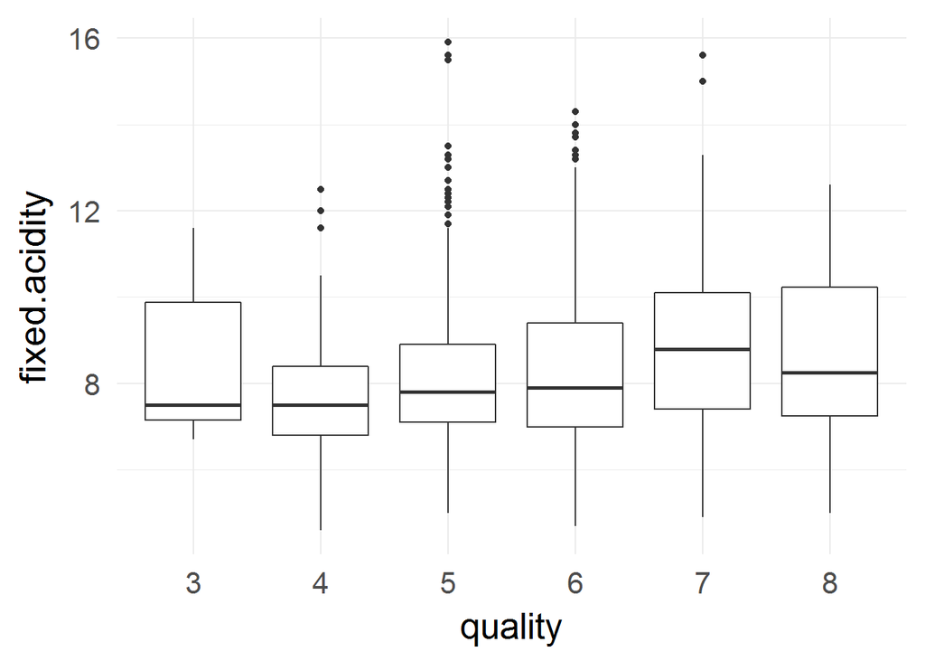

Summaries for fixed.acidity grouped by quality

| quality | mean | median |
| --- | --- | --- |
| 3 | 8.360000 | 7.50 |
| 4 | 7.779245 | 7.50 |
| 5 | 8.167254 | 7.80 |
| 6 | 8.347179 | 7.90 |
| 7 | 8.872362 | 8.80 |
| 8 | 8.566667 | 8.25 |

As the correlation table showed, fixed.acidity seems to have little to no effect on quality.

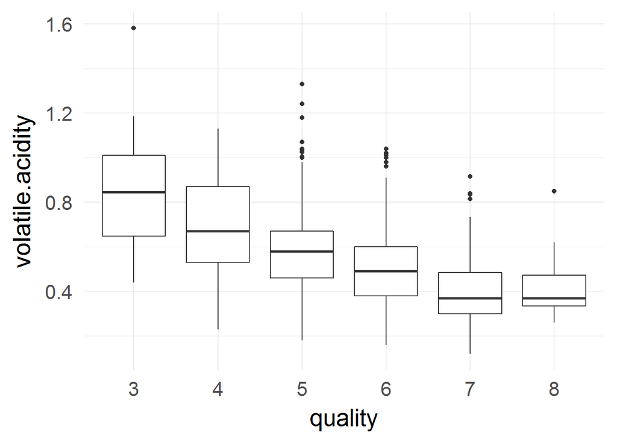

Summaries for volatile.acidity grouped by quality

| quality | mean | median |
| --- | --- | --- |
| 3 | 0.8845000 | 0.845 |
| 4 | 0.6939623 | 0.670 |
| 5 | 0.5770411 | 0.580 |
| 6 | 0.4974843 | 0.490 |
| 7 | 0.4039196 | 0.370 |
| 8 | 0.4233333 | 0.370 |

volatile.acidity has an inverse relationship. Quality seems to go up when volatile.acidity goes down. The higher ranges seem to produce more average and poor wines.

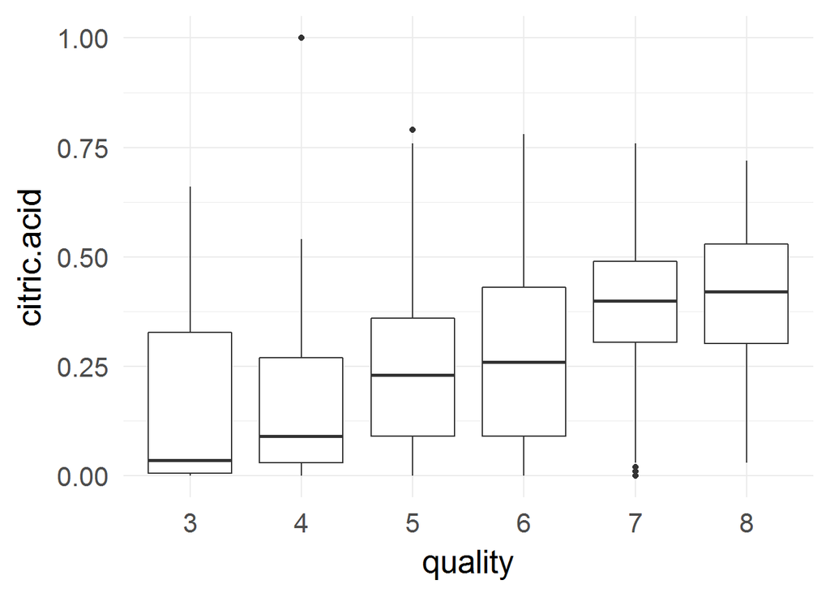

Summaries for citric.acid grouped by quality

| quality | mean | median |
| --- | --- | --- |
| 3 | 0.1710000 | 0.035 |
| 4 | 0.1741509 | 0.090 |
| 5 | 0.2436858 | 0.230 |
| 6 | 0.2738245 | 0.260 |
| 7 | 0.3751759 | 0.400 |
| 8 | 0.3911111 | 0.420 |

A direct proportionality relationship between these two variables. Better wines tend to have higher concentration of citric acid.

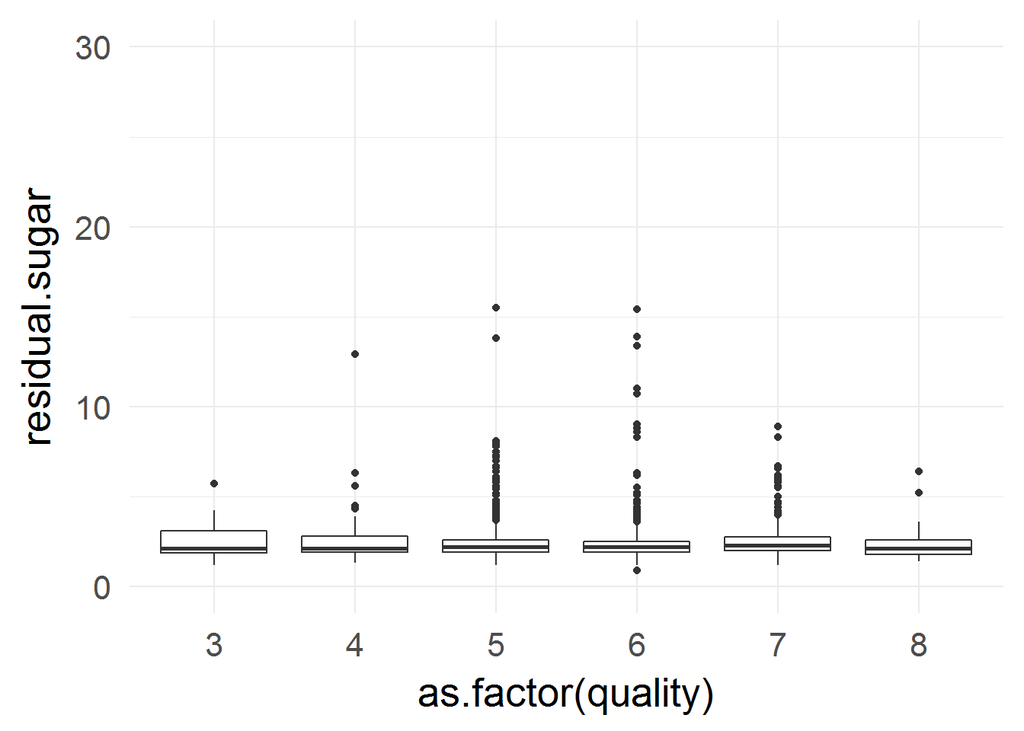

Summaries for residual.sugar grouped by quality

| quality | mean | median |
| --- | --- | --- |
| 3 | 2.635000 | 2.1 |
| 4 | 2.694340 | 2.1 |
| 5 | 2.528855 | 2.2 |
| 6 | 2.477194 | 2.2 |
| 7 | 2.720603 | 2.3 |
| 8 | 2.577778 | 2.1 |

Residual.sugar seems to have little to no effect on perceived quality.

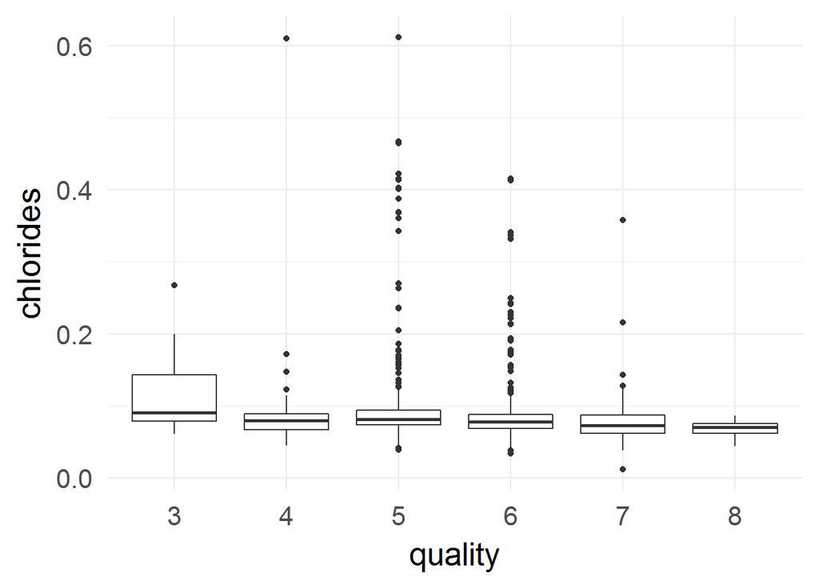

Summaries for chlorides grouped by quality

| quality | mean | median |
| --- | --- | --- |
| 3 | 0.12250000 | 0.0905 |
| 4 | 0.09067925 | 0.0800 |
| 5 | 0.09273568 | 0.0810 |
| 6 | 0.08495611 | 0.0780 |
| 7 | 0.07658794 | 0.0730 |
| 8 | 0.06844444 | 0.0705 |

A lower concentration of chlorides seem to produce better wines.

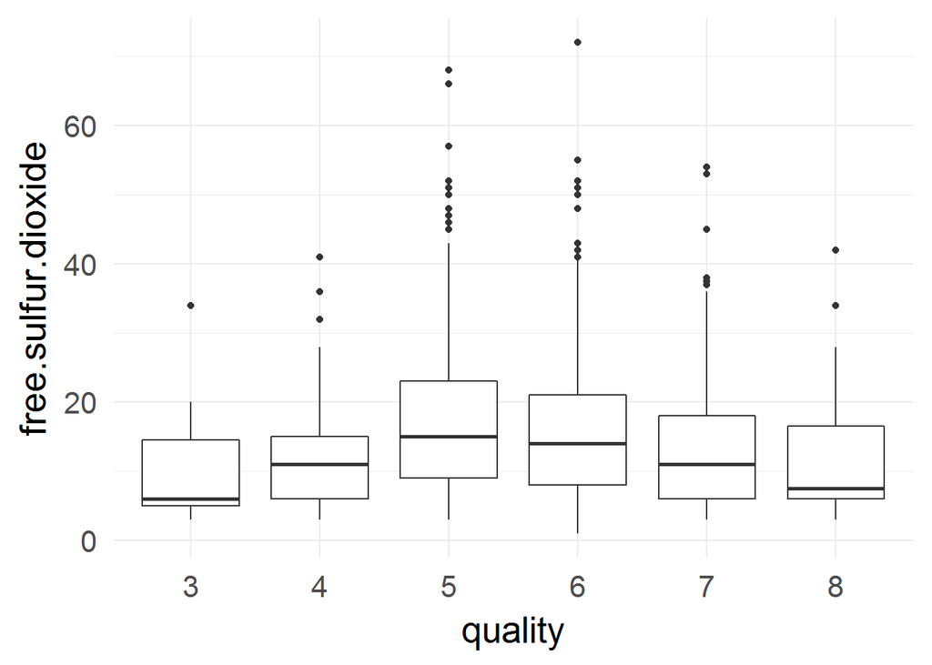

Summaries for free.sulfur.dioxide grouped by quality

| quality | mean | median |
| --- | --- | --- |
| 3 | 11.00000 | 6.0 |
| 4 | 12.26415 | 11.0 |
| 5 | 16.98385 | 15.0 |
| 6 | 15.71160 | 14.0 |
| 7 | 14.04523 | 11.0 |
| 8 | 13.27778 | 7.5 |

Though the ranges are really close to each other it seems that too little sulfur dioxide equals a  
poor quality of wine and too much gives an average quality wine.

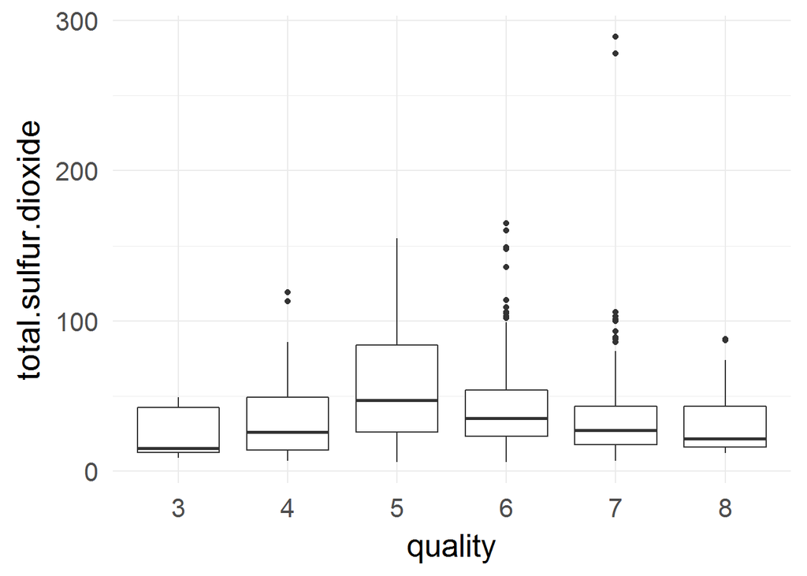

Summaries for total.sulfur.dioxide grouped by quality

| quality | mean | median |
| --- | --- | --- |
| 3 | 24.90000 | 15.0 |
| 4 | 36.24528 | 26.0 |
| 5 | 56.51395 | 47.0 |
| 6 | 40.86991 | 35.0 |
| 7 | 35.02010 | 27.0 |
| 8 | 33.44444 | 21.5 |

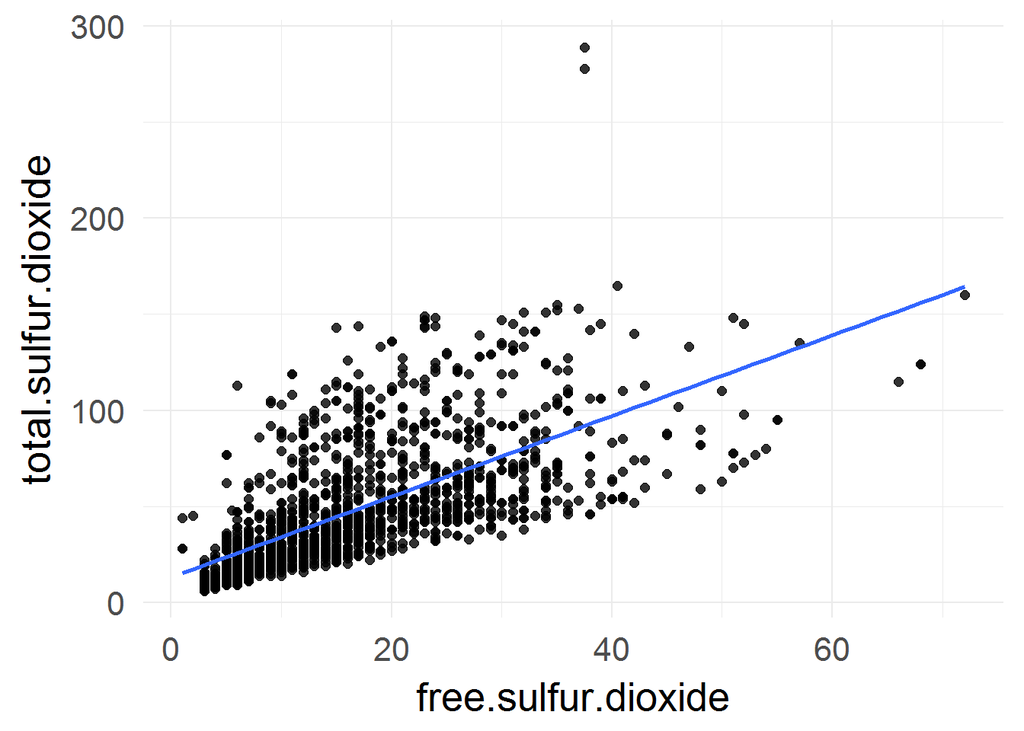

here is a very similar distribution as this is a set of free.sulfur.dioxide.

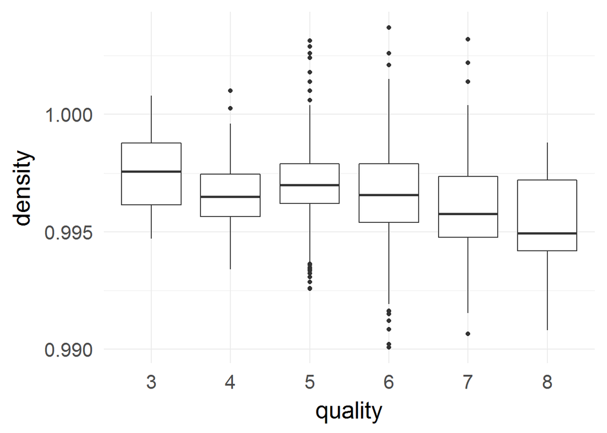

Summaries for density grouped by quality

| quality | mean | median |
| --- | --- | --- |
| 3 | 0.9974640 | 0.997565 |
| 4 | 0.9965425 | 0.996500 |
| 5 | 0.9971036 | 0.997000 |
| 6 | 0.9966151 | 0.996560 |
| 7 | 0.9961043 | 0.995770 |
| 8 | 0.9952122 | 0.994940 |

For better wines quality the density should be lower this is probably due to the alcohol concentration. Maybe we might want to see the effect id alcohol is constant.

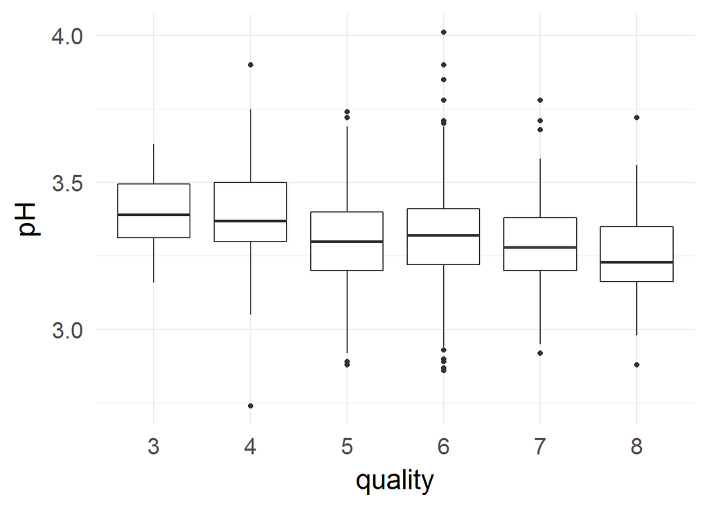

Summaries for pH grouped by quality

| quality | mean | median |
| --- | --- | --- |
| 3 | 3.398000 | 3.39 |
| 4 | 3.381509 | 3.37 |
| 5 | 3.304949 | 3.30 |
| 6 | 3.318072 | 3.32 |
| 7 | 3.290754 | 3.28 |
| 8 | 3.267222 | 3.23 |

Better quality wines ten to be more acidic

Let’s examine how each acid concentration affects pH.

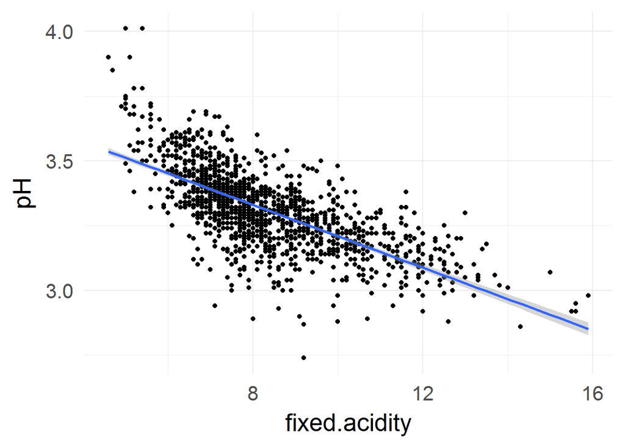

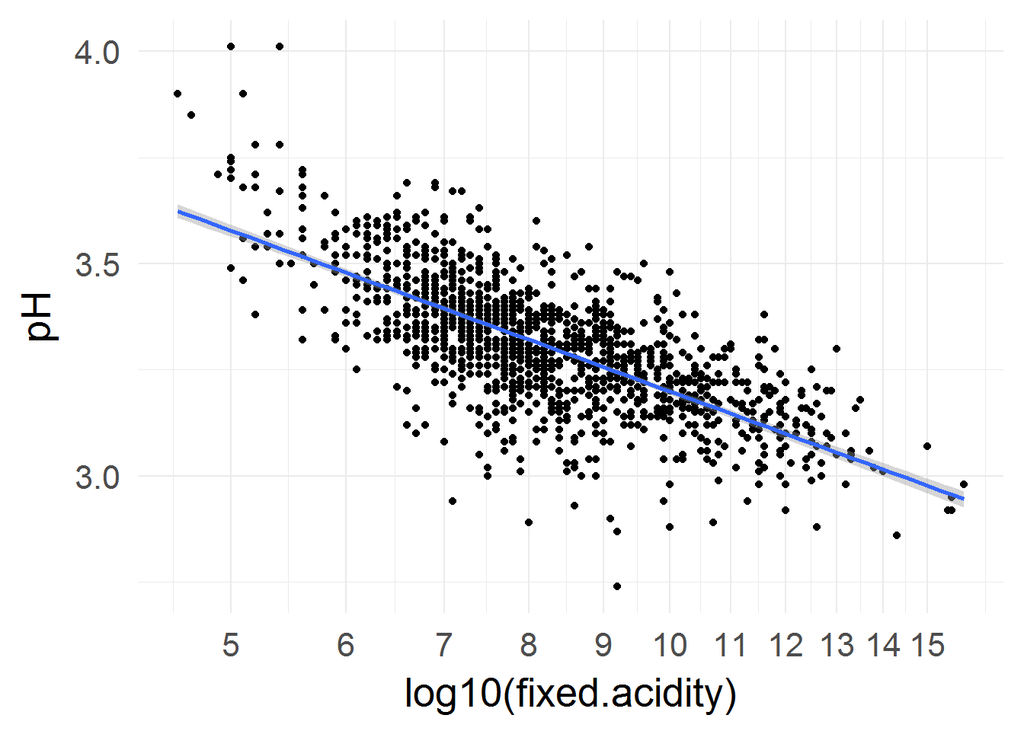

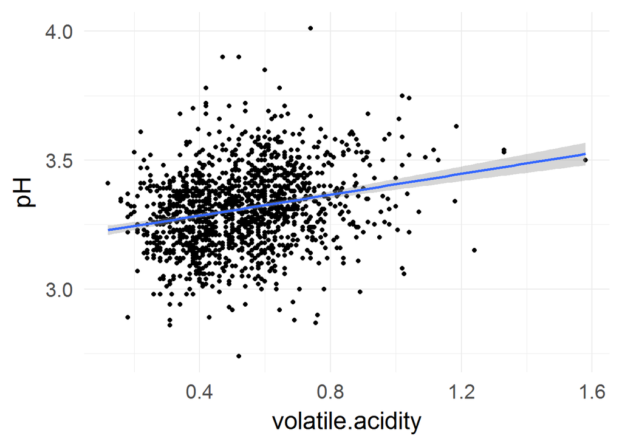

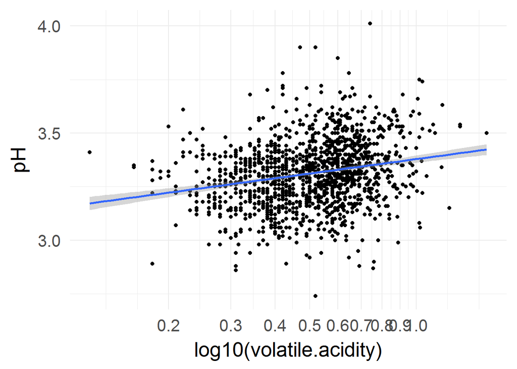

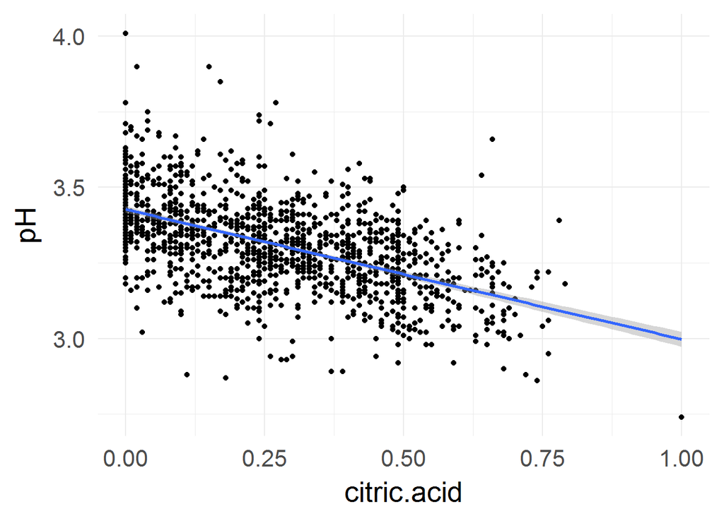

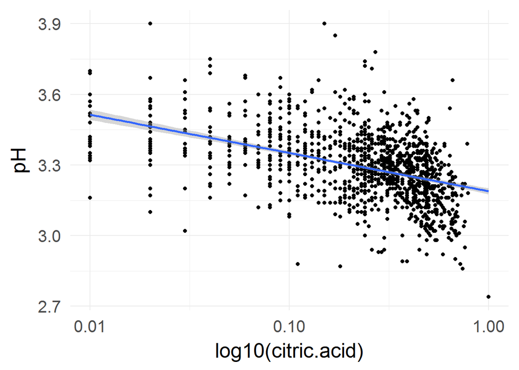

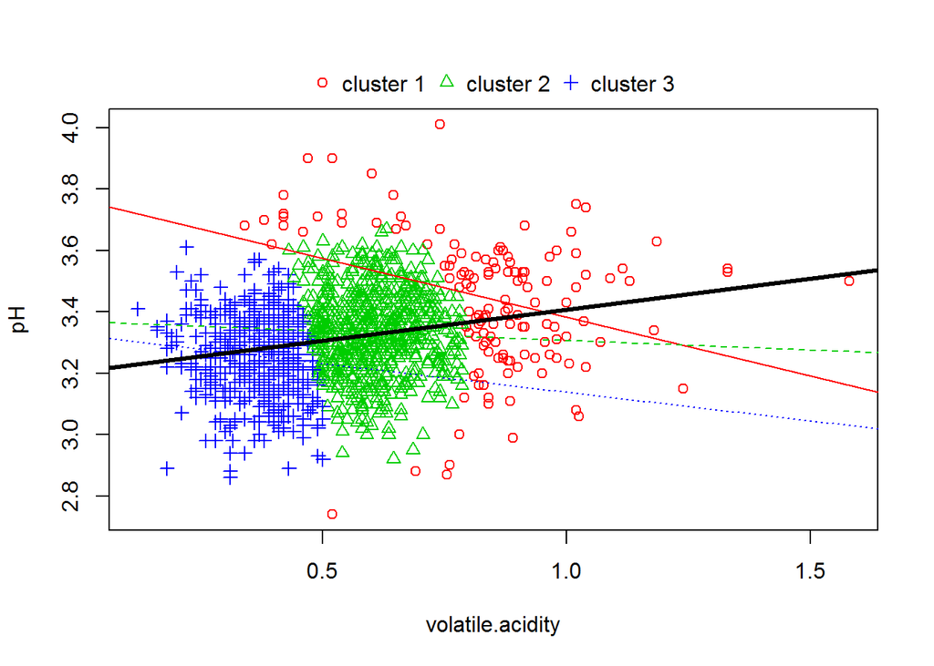

to know if Simpsons Paradox is present, the regression coeficient is recalculated and the data is clusterized. the change in sign indicates that there is a lurking variable distorting the overall coefficient.